# Hate Crime Trends

Candace Todd

December 17, 2019

## Are Hate Crimes a Growing Problem in the U.S?

We’ll approach this question in 2 ways:

**1. Are Hate Crimes happening more often as time goes on?**  
**2. Are Hate Crimes becoming a larger proportion of all crimes committed?**

To answer these questions, we’ll look at Hate Crime Data and General Crime Data From the FBI covering the previous decade (excluding the current year).

### Getting the Data

Upon Inspection, we can see that the FBI data is untidy, has awkward variable names, and has its variables classed in an unhelpful way. When downloading the data from [ucr.fbi.gov](https://ucr.fbi.gov/hate-crime/) I visually verified that the format of each General Crime Table and each Hate Crime Table respectively are almost identical throughout the years, so all tables have been inspected even though here I only preview one of each kind of table.

```r
# Inspecting a Raw FBI General Crime Table
summary(RawCrime2008)
```

```
   Table.5               X2                 X3                 X4                 X5                 X6                 X7                 X8                 X9
 Length:507         Length:507         Length:507         Length:507         Length:507         Length:507         Length:507         Length:507         Length:507
 Class :character   Class :character   Class :character   Class :character   Class :character   Class :character   Class :character   Class :character   Class :character
 Mode  :character   Mode  :character   Mode  :character   Mode  :character   Mode  :character   Mode  :character   Mode  :character   Mode  :character   Mode  :character
     X10                X11                X12                X13                X14
 Length:507         Length:507         Length:507         Length:507         Length:507
 Class :character   Class :character   Class :character   Class :character   Class :character
 Mode  :character   Mode  :character   Mode  :character   Mode  :character   Mode  :character
```

```r
head(RawCrime2008, 15)
```

|  | Table.5 | X2 | X3 | X4 | X5 | X6 | X7 | X8 | X9 | X10 | X11 | X12 | X13 | X14 |
| --- | --- | --- | --- | --- | --- | --- | --- | --- | --- | --- | --- | --- | --- | --- |
| 1 | Crime in the United States | NA | NA |  | NA | NA | NA | NA | NA | NA | NA | NA | NA | NA |
| 2 | by State, 2008 | NA | NA | NA | NA | NA | NA | NA | NA | NA | NA | NA | NA | NA |
| 3 | State | Area | NA | Population | Violent crime | Murder and nonnegligent manslaughter | Forcible rape | Robbery | Aggravated assault | Property crime | Burglary | Larceny-theft | Motor vehicle theft | NA |
| 4 | ALABAMA | Metropolitan Statistical Area | NA | 3328232 | NA | NA | NA | NA | NA | NA | NA | NA | NA |  |
| 5 | NA | NA | Area actually reporting | 0.95799999999999996 | 15781 | 285 | 1119 | 6323 | 8054 | 145200 | 38552 | 95811 | 10837 | NA |
| 6 | NA | NA | Estimated total | 1 | 16207 | 289 | 1157 | 6439 | 8322 | 149171 | 39764 | 98264 | 11143 | NA |
| 7 | NA | Cities outside metropolitan areas | NA | 599012 | NA | NA | NA | NA | NA | NA | NA | NA | NA | NA |
| 8 | NA | NA | Area actually reporting | 0.81599999999999995 | 2972 | 37 | 246 | 654 | 2035 | 24945 | 5801 | 17881 | 1263 | NA |
| 9 | NA | NA | Estimated total | 1 | 3619 | 45 | 299 | 790 | 2485 | 30320 | 7068 | 21714 | 1538 | NA |
| 10 | NA | Nonmetropolitan counties | NA | 734656 | NA | NA | NA | NA | NA | NA | NA | NA | NA | NA |

[output cut: 5 more lines]

```r
# Inspecting a Raw FBI Hate Crime Table
summary(RawHate2008)
```

```
   Table.13              X2                 X3                 X4                 X5                 X6                 X7                 X8                 X9
 Length:2393        Length:2393        Length:2393        Length:2393        Length:2393        Length:2393        Length:2393        Length:2393        Length:2393
 Class :character   Class :character   Class :character   Class :character   Class :character   Class :character   Class :character   Class :character   Class :character
 Mode  :character   Mode  :character   Mode  :character   Mode  :character   Mode  :character   Mode  :character   Mode  :character   Mode  :character   Mode  :character
     X10                X11                X12                X13
 Length:2393        Length:2393        Length:2393        Length:2393
 Class :character   Class :character   Class :character   Class :character
 Mode  :character   Mode  :character   Mode  :character   Mode  :character
```

```r
head(RawHate2008, 12)
```

|  | Table.13 | X2 | X3 | X4 | X5 | X6 | X7 | X8 | X9 | X10 | X11 | X12 | X13 |
| --- | --- | --- | --- | --- | --- | --- | --- | --- | --- | --- | --- | --- | --- |
| 1 | Hate Crime Incidents\nper Bias Motivation and Quarter\nby State and Agency, 2008 | NA | NA | NA | NA | NA | NA | NA | NA | NA | NA | NA | NA |
| 2 | State | Agency type | Agency name | Number of incidents per bias motivation | NA | NA | NA | NA | Number of incidents per quarter1 | NA | NA | NA | Population2 |
| 3 | NA | NA | NA | Race | Religion | Sexual\norientation | Ethnicity | Disability | 1st\nquarter | 2nd\nquarter | 3rd\nquarter | 4th\nquarter | NA |
| 4 | ALABAMA | Total | NA | 6 | 2 | 2 | 1 | 0 | NA | NA | NA | NA | NA |
| 5 | NA | Cities | NA | 3 | 2 | 2 | 1 | 0 | NA | NA | NA | NA | NA |
| 6 | NA | NA | Enterprise | 1 | 0 | 0 | 0 | 0 | 1 | 0 | 0 | 0 | 24863 |
| 7 | NA | NA | Hoover | 2 | 2 | 1 | 1 | 0 | 0 | 1 | 2 | 3 | 70731 |
| 8 | NA | NA | Tuscaloosa | 0 | 0 | 1 | 0 | 0 | 1 | NA | 0 | 0 | 90157 |
| 9 | NA | Metropolitan Counties | NA | 3 | 0 | 0 | 0 | 0 | NA | NA | NA | NA | NA |
| 10 | NA | NA | Lee | 2 | 0 | 0 | 0 | 0 | NA | NA | 1 | 1 | NA |

[output cut: 2 more lines]

### Tidying Up

Before anything can be done with the FBI data, we wrangle them into tidy format.

```r
# Cleaning the Raw FBI Tables
Crime2008 <- as.data.frame(RawCrime2008[-c(1:3),]) # removing header rows for general crime data
Crime2009 <- as.data.frame(RawCrime2009[-c(1:3),])
Crime2010 <- as.data.frame(RawCrime2010[-c(1:3),])
Crime2011 <- as.data.frame(RawCrime2011[-c(1:3),])
Crime2012 <- as.data.frame(RawCrime2012[-c(1:3),])
Crime2013 <- as.data.frame(RawCrime2013[-c(1:3),])
Crime2014 <- as.data.frame(RawCrime2014[-c(1:3),])
Crime2015 <- as.data.frame(RawCrime2015[-c(1:3),])
Crime2016 <- as.data.frame(RawCrime2016[-c(1:3),])
Crime2017 <- as.data.frame(RawCrime2017[-c(1:3),])
Crime2018 <- as.data.frame(RawCrime2018[-c(1:3),])

Hate2008 <- as.data.frame(RawHate2008[-c(1:3),]) # removing header rows for Hate Crime data
Hate2009 <- as.data.frame(RawHate2009[-c(1:3),])
Hate2010 <- as.data.frame(RawHate2010[-c(1:3),])
Hate2011 <- as.data.frame(RawHate2011[-c(1:4),])
Hate2012 <- as.data.frame(RawHate2012[-c(1:5),])
Hate2013 <- as.data.frame(RawHate2013[-c(1:5),])
Hate2014 <- as.data.frame(RawHate2014[-c(1:5),])
Hate2015 <- as.data.frame(RawHate2015[-c(1:5),])
Hate2016 <- as.data.frame(RawHate2016[-c(1:5),])
Hate2017 <- as.data.frame(RawHate2017[-c(1:5),])
Hate2018 <- as.data.frame(RawHate2018[-c(1:5),])

# Verifying
head(Crime2008, 5)
```

|  | Table.5 | X2 | X3 | X4 | X5 | X6 | X7 | X8 | X9 | X10 | X11 | X12 | X13 | X14 |
| --- | --- | --- | --- | --- | --- | --- | --- | --- | --- | --- | --- | --- | --- | --- |
| 4 | ALABAMA | Metropolitan Statistical Area | NA | 3328232 | NA | NA | NA | NA | NA | NA | NA | NA | NA |  |
| 5 | NA | NA | Area actually reporting | 0.95799999999999996 | 15781 | 285 | 1119 | 6323 | 8054 | 145200 | 38552 | 95811 | 10837 | NA |
| 6 | NA | NA | Estimated total | 1 | 16207 | 289 | 1157 | 6439 | 8322 | 149171 | 39764 | 98264 | 11143 | NA |
| 7 | NA | Cities outside metropolitan areas | NA | 599012 | NA | NA | NA | NA | NA | NA | NA | NA | NA | NA |
| 8 | NA | NA | Area actually reporting | 0.81599999999999995 | 2972 | 37 | 246 | 654 | 2035 | 24945 | 5801 | 17881 | 1263 | NA |

```r
head(Hate2008, 5)
```

|  | Table.13 | X2 | X3 | X4 | X5 | X6 | X7 | X8 | X9 | X10 | X11 | X12 | X13 |
| --- | --- | --- | --- | --- | --- | --- | --- | --- | --- | --- | --- | --- | --- |
| 4 | ALABAMA | Total | NA | 6 | 2 | 2 | 1 | 0 | NA | NA | NA | NA | NA |
| 5 | NA | Cities | NA | 3 | 2 | 2 | 1 | 0 | NA | NA | NA | NA | NA |
| 6 | NA | NA | Enterprise | 1 | 0 | 0 | 0 | 0 | 1 | 0 | 0 | 0 | 24863 |
| 7 | NA | NA | Hoover | 2 | 2 | 1 | 1 | 0 | 0 | 1 | 2 | 3 | 70731 |
| 8 | NA | NA | Tuscaloosa | 0 | 0 | 1 | 0 | 0 | 1 | NA | 0 | 0 | 90157 |

##### Continuing the wrangling:

```r
# re-numbering the rows
rownames(Crime2008) <- 1:nrow(Crime2008)
rownames(Hate2008) <- 1:nrow(Hate2008)

# Removing rows that appear to be footnotes
Crime2008 <- as.data.frame(Crime2008[-c(500:504),])
Hate2008 <- as.data.frame(Hate2008[-c(2388:2390),])


tail(Crime2008, 5)
```

|  | Table.5 | X2 | X3 | X4 | X5 | X6 | X7 | X8 | X9 | X10 | X11 | X12 | X13 | X14 |
| --- | --- | --- | --- | --- | --- | --- | --- | --- | --- | --- | --- | --- | --- | --- |
| 495 | NA | NA | Estimated total | 1 | 649 | 4 | 87 | 33 | 525 | 6888 | 927 | 5670 | 291 | NA |
| 496 | NA | Nonmetropolitan counties | NA | 153831 | NA |  | NA |  | NA | NA | NA | NA | NA | NA |
| 497 | NA | NA | Area actually reporting | 1 | 208 | 2 | 28 | 2 | 176 | 1670 | 345 | 1199 | 126 | NA |
| 498 | NA | State Total | NA | 532668 | 1236 | 10 | 180 | 86 | 960 | 14474 | 2184 | 11577 | 713 | NA |
| 499 | NA | NA | Rate per 100,000 inhabitants | NA | 232 | 1.9 | 33.799999999999997 | 16.100000000000001 | 180.2 | 2717.3 | 410 | 2173.4 | 133.9 | NA |

```r
tail(Hate2008, 5)
```

|  | Table.13 | X2 | X3 | X4 | X5 | X6 | X7 | X8 | X9 | X10 | X11 | X12 | X13 |
| --- | --- | --- | --- | --- | --- | --- | --- | --- | --- | --- | --- | --- | --- |
| 2383 | NA | NA | Rock Springs | 0 | 1 | 0 | 0 | 0 | 0 | 0 | 1 | 0 | 19800 |
| 2384 | NA | Metropolitan Counties | NA | 1 | 0 | 0 | 0 | 0 | NA | NA | NA | NA | NA |
| 2385 | NA | NA | Laramie | 1 | 0 | 0 | 0 | 0 | 1 | 0 | 0 | 0 | NA |
| 2386 | NA | Nonmetropolitan Counties | NA | 1 | 0 | 0 | 0 | 0 | NA | NA | NA | NA | NA |
| 2387 | NA | NA | Sublette | 1 | 0 | 0 | 0 | 0 | 0 | 0 | 1 | 0 | NA |

```r
# Renaming the useful columns, re-classing variabels, and dropping (ignoring) columns that aren't of interest to the research question
Crime2008 <-
Crime2008 %>%
  transmute(state = tolower(gsub("(\\d*\\,*\\s*\\d+)$", "", `Table.5`)), # making all lowercase for consistency and removing numbers from states
            total = X2, # In the raw data, the `X2` column actually represents the area of the state where the crime occured,
            population = as.numeric(X4), # but we're only going to end up using the row with the state totals so we're renaming it `total` now.
            violentCrime = as.numeric(X5),#     All other crimes listed are a subset of violent or property crimes (according to the FBI website),
            propertyCrime = as.numeric(X10),#   so we'll only keep these two
            allCrime = (violentCrime + propertyCrime), # Creating variables I anticipate using in the future
            year = 2008
            )
```

```
NAs introduced by coercion
```

```r
Hate2008 <-
Hate2008 %>%
  transmute(state = tolower(gsub("(\\d*\\,*\\s*\\d+)$", "", `Table.13`)),
            race_ethnicity = (as.numeric(X4) + as.numeric(X7)), # Race/Ethnicity/Ancestry is one column in later years so we combine them here
            religion = as.numeric(X5),
            sexualOrientation = as.numeric(X6),
            disability = as.numeric(X8),
            year = 2008
            )

str(Crime2008)
```

```
'data.frame':   499 obs. of  7 variables:
 $ state        : chr  "alabama" NA NA NA ...
 $ total        : chr  "Metropolitan Statistical Area" NA NA "Cities outside metropolitan areas" ...
 $ population   : num  3.33e+06 9.58e-01 1.00 5.99e+05 8.16e-01 ...
 $ violentCrime : num  NA 15781 16207 NA 2972 ...
 $ propertyCrime: num  NA 145200 149171 NA 24945 ...
 $ allCrime     : num  NA 160981 165378 NA 27917 ...
 $ year         : num  2008 2008 2008 2008 2008 ...
```

```r
str(Hate2008)
```

```
'data.frame':   2387 obs. of  6 variables:
 $ state            : chr  "alabama" NA NA NA ...
 $ race_ethnicity   : num  7 4 1 3 0 3 2 1 5 5 ...
 $ religion         : num  2 2 0 2 0 0 0 0 2 2 ...
 $ sexualOrientation: num  2 2 0 1 1 0 0 0 1 1 ...
 $ disability       : num  0 0 0 0 0 0 0 0 0 0 ...
 $ year             : num  2008 2008 2008 2008 2008 ...
```

```r
# Fixing the Crime data so that there's a State name mext to the State total, since the total row is the only one we want to keep

# This for loop will grab the state name from the row above if there is no state name listed in the first column of the row
for (i in 1:nrow(Crime2008)){
  if(is.na(Crime2008[i,1])){
    Crime2008[i,1] <- Crime2008[(i-1),1]
  }
}
# Now the only rows without any NA values are the rows with the State Totals, which are the rows we want
Crime2008 <- na.omit(Crime2008)

# To filter the Hate data for the rows we want, we get rid of all rows who have an NA value in the first column
Hate2008 <-
  Hate2008 %>%
  mutate(Flag = ifelse(is.na(state), "drop", "keep")) %>% # assigning values to rows that give the state totals that I want to keep
  filter(Flag == "keep") %>%
  select(-c(Flag)) # removing my flag variable, as it has served its purpose

head(Crime2008)
```

|  | state | total | population | violentCrime | propertyCrime | allCrime | year |
| --- | --- | --- | --- | --- | --- | --- | --- |
| 10 | alabama | State Total | 4661900 | 21111 | 190343 | 211454 | 2008 |
| 19 | alaska | State Total | 686293 | 4474 | 20124 | 24598 | 2008 |
| 29 | arizona | State Total | 6500180 | 29059 | 278920 | 307979 | 2008 |
| 40 | arkansas | State Total | 2855390 | 14374 | 109508 | 123882 | 2008 |
| 48 | california | State Total | 36756666 | 185173 | 1080747 | 1265920 | 2008 |
| 59 | colorado | State Total | 4939456 | 16946 | 140725 | 157671 | 2008 |

```r
head(Hate2008)
```

|  | state | race_ethnicity | religion | sexualOrientation | disability | year |
| --- | --- | --- | --- | --- | --- | --- |
| 1 | alabama | 7 | 2 | 2 | 0 | 2008 |
| 2 | alaska | 5 | 2 | 1 | 0 | 2008 |
| 3 | arizona | 126 | 34 | 25 | 0 | 2008 |
| 4 | arkansas | 70 | 3 | 18 | 0 | 2008 |
| 5 | california | 800 | 294 | 283 | 4 | 2008 |
| 6 | colorado | 99 | 24 | 24 | 2 | 2008 |

*Here is the hidden block of code that cleans the 2009-2018 data tables*

Some incomplete cleaning tasks that I couldn’t debug slipped through the cracks, so here I employ “search and destroy” tactics.

```r
Crime2008 <- Crime2008 %>%
  filter(state != "puerto rico") %>%
  mutate(state = gsub("2\\,\\s3", "", state),
         state = gsub("\\s+$", "", state))

Crime2009 <- Crime2009 %>%
  filter(state != "puerto rico") %>%
  mutate(state = gsub("2\\,\\s3", "", state),
         state = gsub("\\s+$", "", state))

Crime2013 <- Crime2013 %>%
  filter(state != "puerto rico") %>%
  mutate(state = gsub("4.", "", state),
         state = gsub("5*.*\\s$", "", state))

Crime2014 <- Crime2014 %>%
  mutate(state = gsub("4\\,", "", state)) %>%
  mutate(state = gsub("\\s+$", "", state)) %>%
  filter(state != "puerto rico")

Crime2011 <- filter(Crime2011, state != "puerto rico")
Crime2012 <- filter(Crime2012, state != "puerto rico")
Crime2015 <- filter(Crime2015, state != "puerto rico")
Crime2016 <- filter(Crime2016, state != "puerto rico")
Crime2017 <- filter(Crime2017, state != "puerto rico")
Crime2018 <- filter(Crime2018, state != "puerto rico")

Hate2010 <- Hate2010[-51,]
```

Now we join all the `Crime` tables together and all the `Hate` tables together into longitudinal data tables.

```r
# Joining all data
DecadeOfCrime <-
  full_join(Crime2008, Crime2009) %>%
  full_join(Crime2010) %>%
  full_join(Crime2011) %>%
  full_join(Crime2012) %>%
  full_join(Crime2013) %>%
  full_join(Crime2014) %>%
  full_join(Crime2015) %>%
  full_join(Crime2016) %>%
  full_join(Crime2017) %>%
  full_join(Crime2018) %>%
  select(-c(total))

DecadeOfHate <-
  full_join(Hate2008, Hate2009) %>%
  full_join(Hate2010) %>%
  full_join(Hate2011) %>%
  full_join(Hate2012) %>%
  full_join(Hate2013) %>%
  full_join(Hate2014) %>%
  full_join(Hate2015) %>%
  full_join(Hate2016) %>%
  full_join(Hate2017) %>%
  full_join(Hate2018) %>%
  replace_na(list(gender = 0, genderIdentity = 0))

Decade <-
  full_join(DecadeOfHate, DecadeOfCrime)

head(DecadeOfCrime)
```

|  | state | population | violentCrime | propertyCrime | allCrime | year |
| --- | --- | --- | --- | --- | --- | --- |
| 1 | alabama | 4661900 | 21111 | 190343 | 211454 | 2008 |
| 2 | alaska | 686293 | 4474 | 20124 | 24598 | 2008 |
| 3 | arizona | 6500180 | 29059 | 278920 | 307979 | 2008 |
| 4 | arkansas | 2855390 | 14374 | 109508 | 123882 | 2008 |
| 5 | california | 36756666 | 185173 | 1080747 | 1265920 | 2008 |
| 6 | colorado | 4939456 | 16946 | 140725 | 157671 | 2008 |

```r
head(DecadeOfHate)
```

|  | state | race_ethnicity | religion | sexualOrientation | disability | year | gender | genderIdentity |
| --- | --- | --- | --- | --- | --- | --- | --- | --- |
| 1 | alabama | 7 | 2 | 2 | 0 | 2008 | 0 | 0 |
| 2 | alaska | 5 | 2 | 1 | 0 | 2008 | 0 | 0 |
| 3 | arizona | 126 | 34 | 25 | 0 | 2008 | 0 | 0 |
| 4 | arkansas | 70 | 3 | 18 | 0 | 2008 | 0 | 0 |
| 5 | california | 800 | 294 | 283 | 4 | 2008 | 0 | 0 |
| 6 | colorado | 99 | 24 | 24 | 2 | 2008 | 0 | 0 |

### Analysis

Recall our 2 approaches to the research question:

**1. Are Hate Crimes happening more often as time goes on?**  
**2. Are Hate Crimes becoming a larger proportion of all crimes committed?**

Let’s tackle these one at a time.

**Are Hate Crimes happening more often as time goes on?** To answer this, we need to wrangle our data to express Hate Crime rates for each of the states for every year. We’ll calculate Hate Crime rates the same way we would calculate normal Crime Rates, except we’ll exclusively use the counts from the FBI Hate Crime data. This will gives us a measure of the number of Hate Crimes committed per 100,000 members of the population. Then, we’ll plot these results to see if we can get a feel for the outcome of applying a linear model.

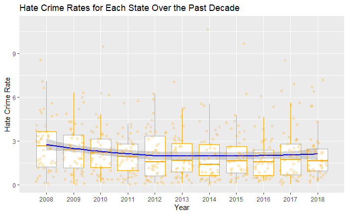

The orange parts of the plot represent the distribution of the states’ Hate Crime rates for that year.

Looking at this plot, it doesn’t seem as though there will be a strong relationship between the year and the Hate Crime Rate.The confidence interval around our smoother is so wide that it doesn’t seem like we’ll be able to see a significant difference in the Hate Crime rates from year to year. However, the smoother does appear to change directions some time between 2013 and 2015. Let’s split the data at 2014 and fit it to two linear models.

[output not shown]

**Are Hate Crimes becoming a larger proportion of all crimes committed?** To answer this, we need to wrangle our data to express the proportions of crimes that were Hate Crime rates for every year. To make a legible plot, we’ll use national yearly summaries instead of grouping data by state.

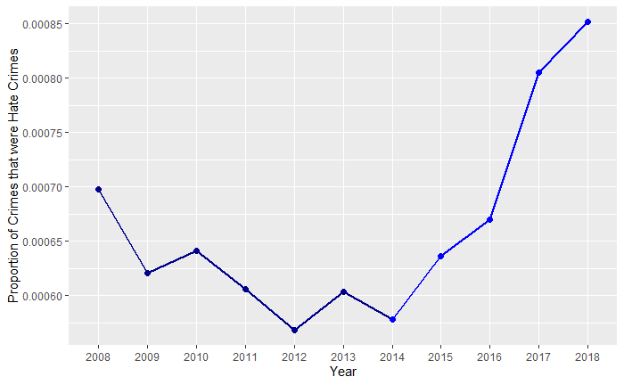

```
Call:
lm(formula = propHate ~ year, data = filter(HateProportions,
    year < 2014))

Residuals:
         1          2          3          4          5          6
 2.738e-05 -3.082e-05  9.065e-06 -7.466e-06 -2.588e-05  2.772e-05

Coefficients:
              Estimate Std. Error t value Pr(>|t|)
(Intercept)  3.886e-02  1.375e-02   2.825   0.0476 *
year        -1.902e-05  6.841e-06  -2.780   0.0498 *
---
Signif. codes:  0 ‘***’ 0.001 ‘**’ 0.01 ‘*’ 0.05 ‘.’ 0.1 ‘ ’ 1

Residual standard error: 2.862e-05 on 4 degrees of freedom
Multiple R-squared:  0.6589,    Adjusted R-squared:  0.5736
F-statistic: 7.727 on 1 and 4 DF,  p-value: 0.04983


Call:
lm(formula = propHate ~ year, data = filter(HateProportions,
    year >= 2014))

Residuals:
         1          2          3          4          5
 1.308e-05 -1.285e-07 -3.864e-05  2.535e-05  3.442e-07

Coefficients:
              Estimate Std. Error t value Pr(>|t|)
(Intercept) -1.435e-01  1.768e-02  -8.116  0.00391 **
year         7.152e-05  8.769e-06   8.156  0.00386 **
---
Signif. codes:  0 ‘***’ 0.001 ‘**’ 0.01 ‘*’ 0.05 ‘.’ 0.1 ‘ ’ 1

Residual standard error: 2.773e-05 on 3 degrees of freedom
Multiple R-squared:  0.9568,    Adjusted R-squared:  0.9425
F-statistic: 66.51 on 1 and 3 DF,  p-value: 0.003855
```

Let’s see if we observe any differences amongst the different kinds of Hate Crimes. Below, the Hate Crimes are separated by the bias of their perpetrator. We are still looking at national summaries.

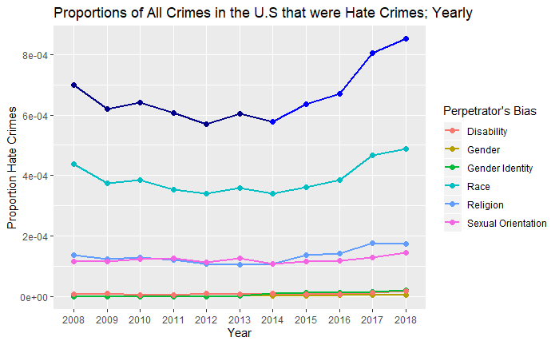

It appears that post-2014, every kind of Hate Crime either became a larger proportion of all crimes committed or stayed the same. Racial bias is consistently dominant amongst the Hate Crimes committed. Religion and Sexual Orientation biases are the next most prevalent, and Gender, Gender Identity, and Disability biases are the least prevalent.

### Conclusion

From this data, we can’t see a clear trend over the past decade but it does seem like there is some important information about Hate Crime trends held in the 2014-2018 data. Unfortunately, the strength of our conclusions is limited due to the inherent missingness that these data sets suffer from: all of the data is self reported by cities and states across the country. The FBI doesn’t require any local governments to submit their crime data to the national government. This gives states and cities the ability to purposefully report less crime in certain areas that they want to make more desirable. In some years, certain states didn’t submit any data at all. It should be noted that the FBI states on their website that definitions of certain crimes has changed over the years. For example, the definition of rape changed in 2011, greatly increasing the number of violent crimes that reported from that year on. It should also be noted that this data suffers from awareness bias. The public’s understanding of what constitutes a Hate Crime can change very easily in the whims of social changes. For example, it’s easier to recognize a Hate Crime as a Hate Crime if the media has recently been reporting on social justice issues. In spite of all this, it does seem evident that Hate Crimes are making up a larger proportion of all crimes committed in the United States in the most recent years. Hopefully a more complete data set can confirm or deny the intuition formed during this analysis.